# Práctica 2.

Lisardo Gayán

José Luis Melo

11 June, 2019

# 1 - Descripción del dataset.

**¿Por qué es importante y qué pregunta/problema pretende responder?**

El dataset de Titanic: Machine Learning from Disaster se registran los datos de los pasajeros del famoso trasatlántico y se utiliza para predecir los supervivientes. Los datos estan divididos en dos dataset, uno de test y otro entrenamiento, para la creación de modelos de predicción.

# 2 - Integración y selección de los datos de interés a analizar

Se importan los datos. Primero el dataset train.

```r
datostrain <- read.csv("./data/train.csv", stringsAsFactors = FALSE, na.strings = c("NA", ""))
str(datostrain)
```

```
## 'data.frame':    891 obs. of  12 variables:
##  $ PassengerId: int  1 2 3 4 5 6 7 8 9 10 ...
##  $ Survived   : int  0 1 1 1 0 0 0 0 1 1 ...
##  $ Pclass     : int  3 1 3 1 3 3 1 3 3 2 ...
##  $ Name       : chr  "Braund, Mr. Owen Harris" "Cumings, Mrs. John Bradley (Florence Briggs Thayer)" "Heikkinen, Miss. Laina" "Futrelle, Mrs. Jacques Heath (Lily May Peel)" ...
##  $ Sex        : chr  "male" "female" "female" "female" ...
##  $ Age        : num  22 38 26 35 35 NA 54 2 27 14 ...
##  $ SibSp      : int  1 1 0 1 0 0 0 3 0 1 ...
##  $ Parch      : int  0 0 0 0 0 0 0 1 2 0 ...
##  $ Ticket     : chr  "A/5 21171" "PC 17599" "STON/O2. 3101282" "113803" ...
##  $ Fare       : num  7.25 71.28 7.92 53.1 8.05 ...
##  $ Cabin      : chr  NA "C85" NA "C123" ...
##  $ Embarked   : chr  "S" "C" "S" "S" ...
```

Se observa como consta de 891 muestras y 12 variables, entre ellas Survived.

Posteriormente el dataset test.

```r
datostest <- read.csv ("./data/test.csv", stringsAsFactors = FALSE, na.strings = c("NA", ""))
str(datostest)
```

```
## 'data.frame':    418 obs. of  11 variables:
##  $ PassengerId: int  892 893 894 895 896 897 898 899 900 901 ...
##  $ Pclass     : int  3 3 2 3 3 3 3 2 3 3 ...
##  $ Name       : chr  "Kelly, Mr. James" "Wilkes, Mrs. James (Ellen Needs)" "Myles, Mr. Thomas Francis" "Wirz, Mr. Albert" ...
##  $ Sex        : chr  "male" "female" "male" "male" ...
##  $ Age        : num  34.5 47 62 27 22 14 30 26 18 21 ...
##  $ SibSp      : int  0 1 0 0 1 0 0 1 0 2 ...
##  $ Parch      : int  0 0 0 0 1 0 0 1 0 0 ...
##  $ Ticket     : chr  "330911" "363272" "240276" "315154" ...
##  $ Fare       : num  7.83 7 9.69 8.66 12.29 ...
##  $ Cabin      : chr  NA NA NA NA ...
##  $ Embarked   : chr  "Q" "S" "Q" "S" ...
```

Se compone de 418 observaciones y 11 variables. La variable Survived no aparece debido a que es la que se debe predecir.

A continuacion, a la hora de fusionar los datos caben dos posibilidades, asignar “NA” a la variable datostest$Survived o no considerar los datos de survived en train. Se importan, fusionan los datos y se revisa la estructura inicial de los datos.

```r
datostest$Survived <- NA
datos <- rbind(datostrain, datostest)
str(datos)
```

```
## 'data.frame':    1309 obs. of  12 variables:
##  $ PassengerId: int  1 2 3 4 5 6 7 8 9 10 ...
##  $ Survived   : int  0 1 1 1 0 0 0 0 1 1 ...
##  $ Pclass     : int  3 1 3 1 3 3 1 3 3 2 ...
##  $ Name       : chr  "Braund, Mr. Owen Harris" "Cumings, Mrs. John Bradley (Florence Briggs Thayer)" "Heikkinen, Miss. Laina" "Futrelle, Mrs. Jacques Heath (Lily May Peel)" ...
##  $ Sex        : chr  "male" "female" "female" "female" ...
##  $ Age        : num  22 38 26 35 35 NA 54 2 27 14 ...
##  $ SibSp      : int  1 1 0 1 0 0 0 3 0 1 ...
##  $ Parch      : int  0 0 0 0 0 0 0 1 2 0 ...
##  $ Ticket     : chr  "A/5 21171" "PC 17599" "STON/O2. 3101282" "113803" ...
##  $ Fare       : num  7.25 71.28 7.92 53.1 8.05 ...
##  $ Cabin      : chr  NA "C85" NA "C123" ...
##  $ Embarked   : chr  "S" "C" "S" "S" ...
```

A continuación comprobamos los datos que faltan.

```r
# Buscamos primero qué variables tienen valores perdidos
missing_numbers <- sapply(datos, function(x) {sum(is.na(x))})
kable(data.frame(Variables = names(missing_numbers), Datos_faltantes= as.vector(missing_numbers))) %>%
  kable_styling(bootstrap_options = "striped", full_width = F, position = "left")
```

| Variables | Datos_faltantes |
| --- | --- |
| PassengerId | 0 |
| Survived | 418 |
| Pclass | 0 |
| Name | 0 |
| Sex | 0 |
| Age | 263 |
| SibSp | 0 |
| Parch | 0 |
| Ticket | 0 |
| Fare | 1 |
| Cabin | 1014 |
| Embarked | 2 |

Podemos observar, que en Survived, salen los 418, que tenemos que predecir, por lo que todos los valores de train están informados.

A continuación se detallan las variables y su tipo inicial, este último, se modificara para su mejor análisis.

```r
# datostrain1 <- datostrain[,-2]
# data <- rbind(datostrain1, datostest) # Fusion datasets
data <- datos[,-2]
str(data)
```

```
## 'data.frame':    1309 obs. of  11 variables:
##  $ PassengerId: int  1 2 3 4 5 6 7 8 9 10 ...
##  $ Pclass     : int  3 1 3 1 3 3 1 3 3 2 ...
##  $ Name       : chr  "Braund, Mr. Owen Harris" "Cumings, Mrs. John Bradley (Florence Briggs Thayer)" "Heikkinen, Miss. Laina" "Futrelle, Mrs. Jacques Heath (Lily May Peel)" ...
##  $ Sex        : chr  "male" "female" "female" "female" ...
##  $ Age        : num  22 38 26 35 35 NA 54 2 27 14 ...
##  $ SibSp      : int  1 1 0 1 0 0 0 3 0 1 ...
##  $ Parch      : int  0 0 0 0 0 0 0 1 2 0 ...
##  $ Ticket     : chr  "A/5 21171" "PC 17599" "STON/O2. 3101282" "113803" ...
##  $ Fare       : num  7.25 71.28 7.92 53.1 8.05 ...
##  $ Cabin      : chr  NA "C85" NA "C123" ...
##  $ Embarked   : chr  "S" "C" "S" "S" ...
```

```r
tipos <- sapply(data, class)
kable(data.frame(Variables = names(tipos), Tipo_Variable= as.vector(tipos))) %>%
  kable_styling(bootstrap_options = "striped", full_width = F, position = "left")
```

| Variables | Tipo_Variable |
| --- | --- |
| PassengerId | integer |
| Pclass | integer |
| Name | character |
| Sex | character |
| Age | numeric |
| SibSp | integer |
| Parch | integer |
| Ticket | character |
| Fare | numeric |
| Cabin | character |
| Embarked | character |

Las variables, que no tienen datos faltantes, class y sex, se convertiran a factor. La variable cabin tiene muchos datos faltantes, así que en un primer momento no se utilizará.

```r
#data$Age <- as.integer(data$Age)
data$Pclass <- as.factor(data$Pclass)
data$Sex <- as.factor(data$Sex)
#data$Embarked <- as.factor(data$Embarked)
#data$Cabin <- as.factor(data$Cabin)
tipos_new <- sapply(data, class)
kable(data.frame(Variables = names(tipos_new), Tipo_Variable= as.vector(tipos_new))) %>%
  kable_styling(bootstrap_options = "striped", full_width = F, position = "left")
```

| Variables | Tipo_Variable |
| --- | --- |
| PassengerId | integer |
| Pclass | factor |
| Name | character |
| Sex | factor |
| Age | numeric |
| SibSp | integer |
| Parch | integer |
| Ticket | character |
| Fare | numeric |
| Cabin | character |
| Embarked | character |

Una vez modificadas los tipos de valores se resume que:

```r
summary(data)
```

```
##   PassengerId   Pclass      Name               Sex           Age
##  Min.   :   1   1:323   Length:1309        female:466   Min.   : 0.17
##  1st Qu.: 328   2:277   Class :character   male  :843   1st Qu.:21.00
##  Median : 655   3:709   Mode  :character                Median :28.00
##  Mean   : 655                                           Mean   :29.88
##  3rd Qu.: 982                                           3rd Qu.:39.00
##  Max.   :1309                                           Max.   :80.00
##                                                         NA's   :263
##      SibSp            Parch          Ticket               Fare
##  Min.   :0.0000   Min.   :0.000   Length:1309        Min.   :  0.000
##  1st Qu.:0.0000   1st Qu.:0.000   Class :character   1st Qu.:  7.896
##  Median :0.0000   Median :0.000   Mode  :character   Median : 14.454
##  Mean   :0.4989   Mean   :0.385                      Mean   : 33.295
##  3rd Qu.:1.0000   3rd Qu.:0.000                      3rd Qu.: 31.275
##  Max.   :8.0000   Max.   :9.000                      Max.   :512.329
##                                                      NA's   :1
##     Cabin             Embarked
##  Length:1309        Length:1309
##  Class :character   Class :character
##  Mode  :character   Mode  :character
##
##
##
##
```

# 3 - Limpieza de datos

**3.1. ¿Los datos contienen ceros o elementos vacíos? ¿Cómo gestionarías cada uno de estos casos?**

Volvemos a mostrar los datos que contienen ceros o elementos vacíos.

```r
# Busco primero qué variables tienen valores perdidos
missing_numbers <- sapply(datos, function(x) {sum(is.na(x))})
kable(data.frame(Variables = names(missing_numbers),
                 Datos_faltantes= as.vector(missing_numbers))) %>%
  kable_styling(bootstrap_options = "striped", full_width = F, position = "left")
```

| Variables | Datos_faltantes |
| --- | --- |
| PassengerId | 0 |
| Survived | 418 |
| Pclass | 0 |
| Name | 0 |
| Sex | 0 |
| Age | 263 |
| SibSp | 0 |
| Parch | 0 |
| Ticket | 0 |
| Fare | 1 |
| Cabin | 1014 |
| Embarked | 2 |

De las variables existentes a continuación se espedifican aquellas que contienen valores perdido o nulos.

- Age: *existen 263 valores nulos.*

Para imputar valores de **edad**, se aplicara el algoritmo rpart, que es un árbol de regresión.

Comprobamos la variable Age

```r
summary(data$Age)
```

```
##    Min. 1st Qu.  Median    Mean 3rd Qu.    Max.    NA's
##    0.17   21.00   28.00   29.88   39.00   80.00     263
```

Se comprueba como hay 263 valores nulos.

```r
# Referencia:
# https://www.rdocumentation.org/packages/rpart/versions/4.1-15/topics/rpart
age_model <- rpart(Age ~ Pclass + Sex + SibSp + Parch + Fare + Embarked,
                       data = data[!is.na(data$Age),], method = "anova")
data$Age[is.na(data$Age)] <- predict(age_model, data[is.na(data$Age),])
summary(data$Age)
```

```
##    Min. 1st Qu.  Median    Mean 3rd Qu.    Max.
##    0.17   22.00   27.43   29.63   37.00   80.00
```

También se podrían imputar por otros métodos, como la media, mediana o mice en lugar del usado rpart.

- Fare: *existe 1 valor nulo.*  
  Para imputar valores **Fare**  
  Dado que unicamente hay un valor perdido, es posible imputarlo por la media o la mediana en base al puerto de embarque “S” y la clase “3”

```r
data[is.na(data$Fare),]
```

```
##      PassengerId Pclass               Name  Sex  Age SibSp Parch Ticket
## 1044        1044      3 Storey, Mr. Thomas male 60.5     0     0   3701
##      Fare Cabin Embarked
## 1044   NA  <NA>        S
```

```r
M_fare<- subset(data,data$Pclass == '3' & data$Embarked == 'S')
mean(M_fare$Fare, na.rm = T)
```

```
## [1] 14.43542
```

```r
median(M_fare$Fare, na.rm = T)
```

```
## [1] 8.05
```

Realizamos una gráfica de la distribución de valores de Fare.

```
## Warning: Removed 1 rows containing non-finite values (stat_density).
```

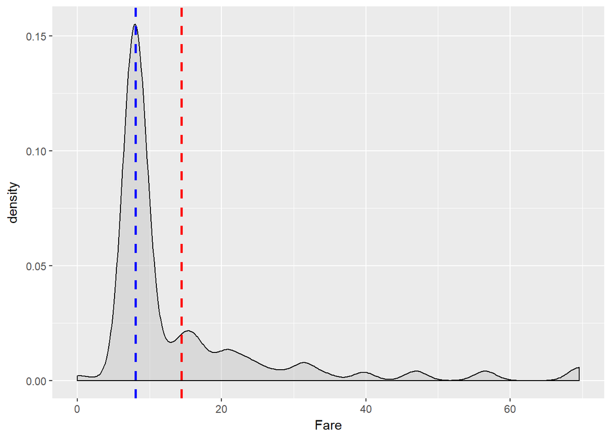

```r
ggplot(M_fare,  aes(x = Fare)) +
  geom_density(fill = 'grey', alpha=0.4) +
  geom_vline(aes(xintercept=median(Fare, na.rm=T)),
    colour='blue', linetype='dashed', lwd=1) +
  geom_vline(aes(xintercept=mean(Fare, na.rm=T)),
  colour='red', linetype='dashed', lwd=1)
```

Observamos como al realizar la gráfica la advertencia *“Removed 1 rows containing non-finite values (stat_density)”* nos indica que hay un valor nulo.

La tarifa de 8.05 coincide con la mediana de los pasajeros de tercera clase que embarcaron en S, por lo que se podría imputar este valor.

```r
data$Fare[c(1044)] <- 8.05
data[1044,]
```

```
##      PassengerId Pclass               Name  Sex  Age SibSp Parch Ticket
## 1044        1044      3 Storey, Mr. Thomas male 60.5     0     0   3701
##      Fare Cabin Embarked
## 1044 8.05  <NA>        S
```

Volviendo a representar

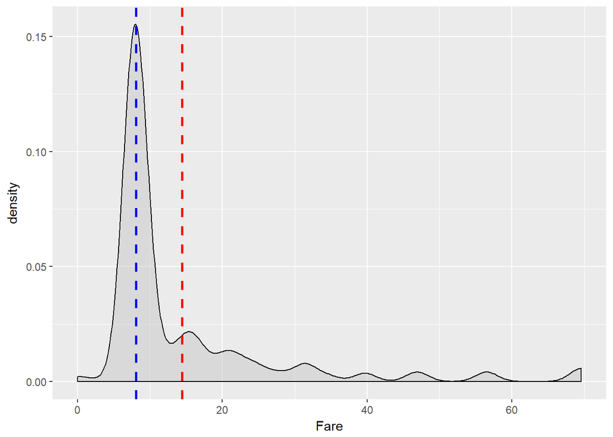

```r
M_fare<- subset(data,data$Pclass == '3' & data$Embarked == 'S')
ggplot(M_fare,  aes(x = Fare)) +
  geom_density(fill = 'grey', alpha=0.4) +
  geom_vline(aes(xintercept=median(Fare, na.rm=T)),
    colour='blue', linetype='dashed', lwd=1) +
  geom_vline(aes(xintercept=mean(Fare, na.rm=T)),
  colour='red', linetype='dashed', lwd=1)
```

Una vez imputado el valor ya no existe advertencia lo que significa que en Fare ya no hay un valor nulo.

- Cabin: *existen 1014 valores perdidos.*  
  Para imputar valores **Cabin**  
  Esta variable tiene muchos valores perdidos, se podria conseguir predecir la cubierta asignada al pasajero pero es un dato que poco beneficio podría traer ya que se puede realizar el analisis con la combinación entre la tarifa y la clase del pasajero.
- Embarked: *existen 2 valores perdidos.*  
  Para imputar valores **Embarked**

Mostramos los valores perdidos

```r
data[is.na(data$Embarked),]
```

```
##     PassengerId Pclass                                      Name    Sex
## 62           62      1                       Icard, Miss. Amelie female
## 830         830      1 Stone, Mrs. George Nelson (Martha Evelyn) female
##     Age SibSp Parch Ticket Fare Cabin Embarked
## 62   38     0     0 113572   80   B28     <NA>
## 830  62     0     0 113572   80   B28     <NA>
```

Al ser unicamente dos valores perdidos, se podría sustituir los valores por la media, en base a otros pasajeros de la misma clase y tarifa (Fare). Los pasajeros han pagado una tarifa de 80 y pertenecian a primera clase.

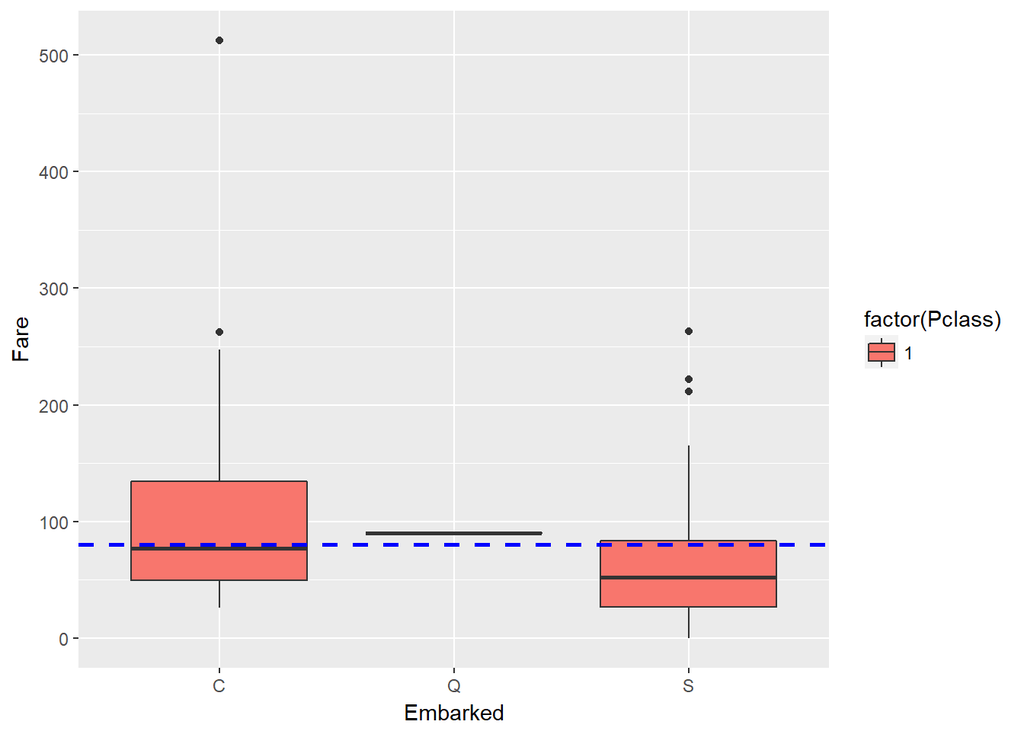

```r
embarked_pass_1 <- data %>%
  filter(PassengerId != 62 & PassengerId != 830 & Pclass == 1)
ggplot(embarked_pass_1, aes(x = Embarked, y = Fare, fill = factor(Pclass))) +
  geom_boxplot() +
  geom_hline(aes(yintercept=80),
    colour='blue', linetype='dashed', lwd=1)
```

La tarifa de 80 coincide con la media de los pasajeros de primera clase que embarcaron en C, por lo que se podría imputar este puerto.

```r
data$Embarked[c(62, 830)] <- 'C'
```

Otra opción, sería considerar también el sexo, ya que principios del siglo XX, no se caracterizaba por una igualdad de hombres y mujeres.

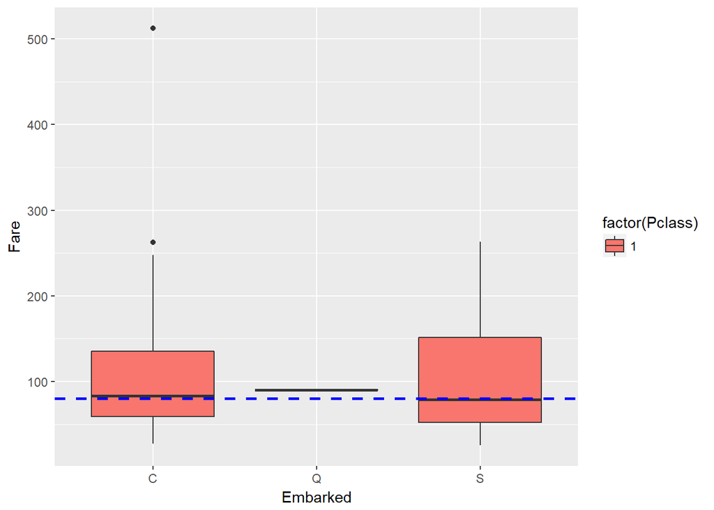

```r
embarked_pass_2 <- data %>%
  filter(PassengerId != 62 & PassengerId != 830 & Pclass == 1 & Sex == "female")
ggplot(embarked_pass_2, aes(x = Embarked, y = Fare, fill = factor(Pclass))) +
  geom_boxplot() +
  geom_hline(aes(yintercept=80),
    colour='blue', linetype='dashed', lwd=1)
```

En este caso cualquiera de los 3 puertos tendría una media cercana a 80. Como no creemos que el puerto de embarque este correlacionado con la supervivencia, podríamos dejar cualquiera.

Otra forma de asignar el valor de los puertos de embarque sería asignar el valor más frequente. Calculamos cuantas veces aparece cada puerto de embarque.

```r
table(data$Embarked)
```

```
##
##   C   Q   S
## 272 123 914
```

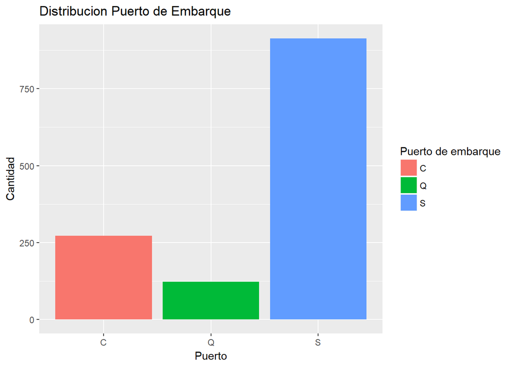

```r
qplot(Embarked, data = data,  fill= Embarked) +
  labs (title = "Distribucion Puerto de Embarque",
        x= "Puerto", y = "Cantidad", fill = "Puerto de embarque")
```

Se muestra como el puerto con mayor frequencia es S, así que finalmente asignaremos este valor.

```r
data$Embarked[c(62, 830)] <- 'S'
```

A continuación trataremos la variable Name, para crear una variable Title, que nos aporte algo de información.

A partir de Name obtenemos el título de los nombres

```r
# Mostramos algunos nombres
head(data$Name)
```

```
## [1] "Braund, Mr. Owen Harris"
## [2] "Cumings, Mrs. John Bradley (Florence Briggs Thayer)"
## [3] "Heikkinen, Miss. Laina"
## [4] "Futrelle, Mrs. Jacques Heath (Lily May Peel)"
## [5] "Allen, Mr. William Henry"
## [6] "Moran, Mr. James"
```

Podemos clasificar a las personas por su título.

```r
# Grab passenger title from passenger name
# Referencia:
# https://www.kaggle.com/thilakshasilva/predicting-titanic-survival-using-five-algorithms
data$Title <- gsub("^.*, (.*?)\\..*$", "\\1", data$Name)
```

Mostramos los títulos de las personas que viajaban en el Titanic

```r
#Mostramos la variable Title en función de sex
kable(table(data$Title, data$Sex)) %>%
  kable_styling(bootstrap_options = "striped", full_width = F, position = "left")
```

|  | female | male |
| --- | --- | --- |
| Capt | 0 | 1 |
| Col | 0 | 4 |
| Don | 0 | 1 |
| Dona | 1 | 0 |
| Dr | 1 | 7 |
| Jonkheer | 0 | 1 |
| Lady | 1 | 0 |
| Major | 0 | 2 |
| Master | 0 | 61 |
| Miss | 260 | 0 |
| Mlle | 2 | 0 |
| Mme | 1 | 0 |
| Mr | 0 | 757 |
| Mrs | 197 | 0 |
| Ms | 2 | 0 |
| Rev | 0 | 8 |
| Sir | 0 | 1 |
| the Countess | 1 | 0 |

Podemos reasignar las “Mlle” (Madmoiselle) y “Ms” a “Miss”, señoritas y la “Mme” (Madame) a “Mrs” (señora). Las ocurrencias con poca frecuencia las podemos agrupar en otros “Other”.

```r
# Reagrupando
data$Title[data$Title == 'Mlle' | data$Title == 'Ms'] <- 'Miss'
data$Title[data$Title == 'Mme']  <- 'Mrs'
Other <- c('Dona', 'Dr', 'Lady', 'the Countess','Capt', 'Col', 'Don', 'Jonkheer', 'Major', 'Rev', 'Sir')
data$Title[data$Title %in% Other]  <- 'Other'
```

Volviendo a representarlos en función del sexo.

```r
# Mostramos el título en función del sexo
kable(table(data$Title, data$Sex)) %>%
  kable_styling(bootstrap_options = "striped", full_width = F, position = "left")
```

|  | female | male |
| --- | --- | --- |
| Master | 0 | 61 |
| Miss | 264 | 0 |
| Mr | 0 | 757 |
| Mrs | 198 | 0 |
| Other | 4 | 25 |

La variable Age se podría discretizar y a partir de SibSp y Parch se podría crear una variable con el tamaño de la familia, pero realizaremos un modelo más sencillo, con las variables tratadas hasta ahora.

Una vez añadidos los valores faltantes, se convierten las variables Embarked y Title a factor.

```r
data$Embarked <- as.factor(data$Embarked)
data$Title <- as.factor(data$Title)
```

Volvemos a añadir la variable Survived y la convertimos a factor.

```r
data$Survived <- datos$Survived
data$Survived <- as.factor(data$Survived)
```

Volvemos a mostrar la tabla con el número de valores faltantes. Recordar que en data, no están los valores de la variable Survived.

```r
# Busco primero qué variables tienen valores perdidos
missing_numbers <- sapply(data, function(x) {sum(is.na(x))})
kable(data.frame(Variables = names(missing_numbers),
                 Datos_faltantes= as.vector(missing_numbers))) %>%
  kable_styling(bootstrap_options = "striped",
                full_width = F, position = "left")
```

| Variables | Datos_faltantes |
| --- | --- |
| PassengerId | 0 |
| Pclass | 0 |
| Name | 0 |
| Sex | 0 |
| Age | 0 |
| SibSp | 0 |
| Parch | 0 |
| Ticket | 0 |
| Fare | 0 |
| Cabin | 1014 |
| Embarked | 0 |
| Title | 0 |
| Survived | 418 |

Representamos la tabla con los tipos de los valores.

```r
tipos_new <- sapply(data, class)
kable(data.frame(Variables = names(tipos_new), Tipo_Variable= as.vector(tipos_new))) %>%
  kable_styling(bootstrap_options = "striped", full_width = F, position = "left")
```

| Variables | Tipo_Variable |
| --- | --- |
| PassengerId | integer |
| Pclass | factor |
| Name | character |
| Sex | factor |
| Age | numeric |
| SibSp | integer |
| Parch | integer |
| Ticket | character |
| Fare | numeric |
| Cabin | character |
| Embarked | factor |
| Title | factor |
| Survived | factor |

**3.2. Identificación y tratamiento de valores extremos.**

Los valores extremos tendrían sentido en los campos Fare y Age. Procedemos al análisis de los valores extremos representando Fare y Age con los valores extremos y sin ellos.

```r
# Referencia:
# https://www.r-bloggers.com/identify-describe-plot-and-remove-the-outliers-from-the-dataset/
outlierKD <- function(dt, var) {
     var_name <- eval(substitute(var),eval(dt))
     na1 <- sum(is.na(var_name))
     m1 <- mean(var_name, na.rm = T)
     par(mfrow=c(2, 2), oma=c(0,0,3,0))
     boxplot(var_name, main="With outliers")
     hist(var_name, main="With outliers", xlab=NA, ylab=NA)
     outlier <- boxplot.stats(var_name)$out
     mo <- mean(outlier)
     var_name <- ifelse(var_name %in% outlier, NA, var_name)
     boxplot(var_name, main="Without outliers")
     hist(var_name, main="Without outliers", xlab=NA, ylab=NA)
     title("Outlier Check", outer=TRUE)
     na2 <- sum(is.na(var_name))
     cat("Outliers identified:", na2 - na1, "n")
     cat("Propotion (%) of outliers:", round((na2 - na1) / sum(!is.na(var_name))*100, 1), "n")
     cat("Mean of the outliers:", round(mo, 2), "n")
     m2 <- mean(var_name, na.rm = T)
     ###
     # cat("Mean without removing outliers:", round(m1, 2), "n")
     # cat("Mean if we remove outliers:", round(m2, 2), "n")
     # response <- readline(prompt="Do you want to remove outliers and to replace with NA? [yes/no]: ")
     # if(response == "y" | response == "yes"){
     #      dt[as.character(substitute(var))] <- invisible(var_name)
     #      assign(as.character(as.list(match.call())$dt), dt, envir = .GlobalEnv)
     #      cat("Outliers successfully removed", "n")
     #      return(invisible(dt))
     # } else{
     #      cat("Nothing changed", "n")
     #      return(invisible(var_name))
     # }
     ###
}
```

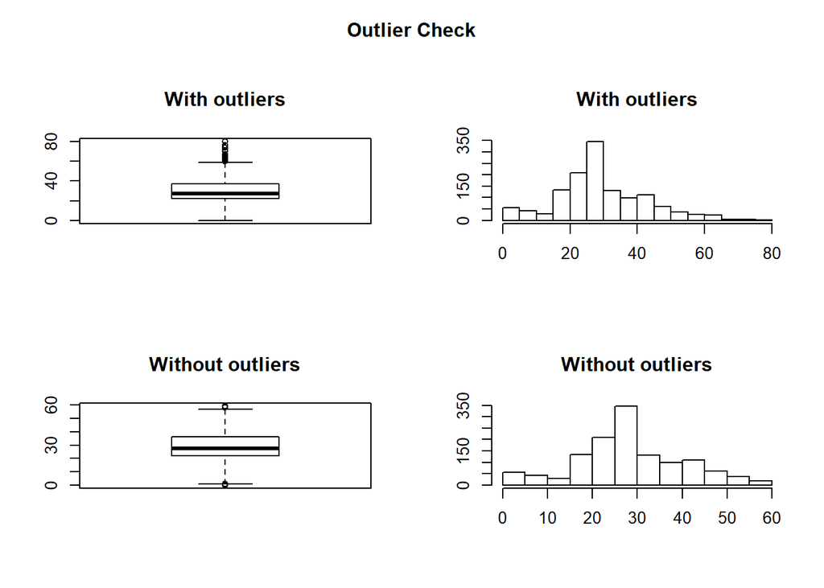

```
## Outliers identified: 40 nPropotion (%) of outliers: 3.2 nMean of the outliers: 64.45 n
```

```r
outlierKD(data, Age)
```

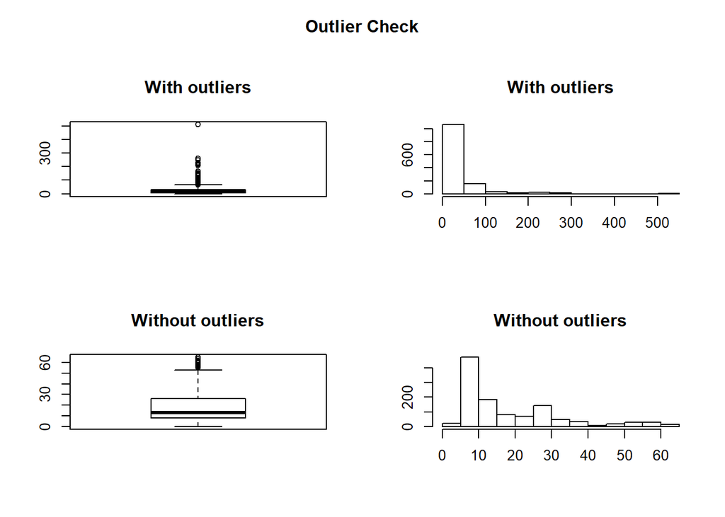

```
## Outliers identified: 171 nPropotion (%) of outliers: 15 nMean of the outliers: 135.25 n
```

```r
outlierKD(data, Fare)
```

Como son perfectamente aceptables las edades y que haya gente que pagara mucho más por su billete, al ser el primer viaje del transatlántico más grande de la epoca, decidimos no cambiar ningún valor.

# 4. Análisis de los datos.

**4.1. Selección de los grupos de datos que se quieren analizar/comparar (planificación de los análisis a aplicar)**

- Análisis estadístico descriptivo.

Se utilizarán las variables de Edad, Clase, Género y Puerto de Embarque para realizar el análisis de los datos.

La distribución de los pasajeros según indica el siguiente grafico.

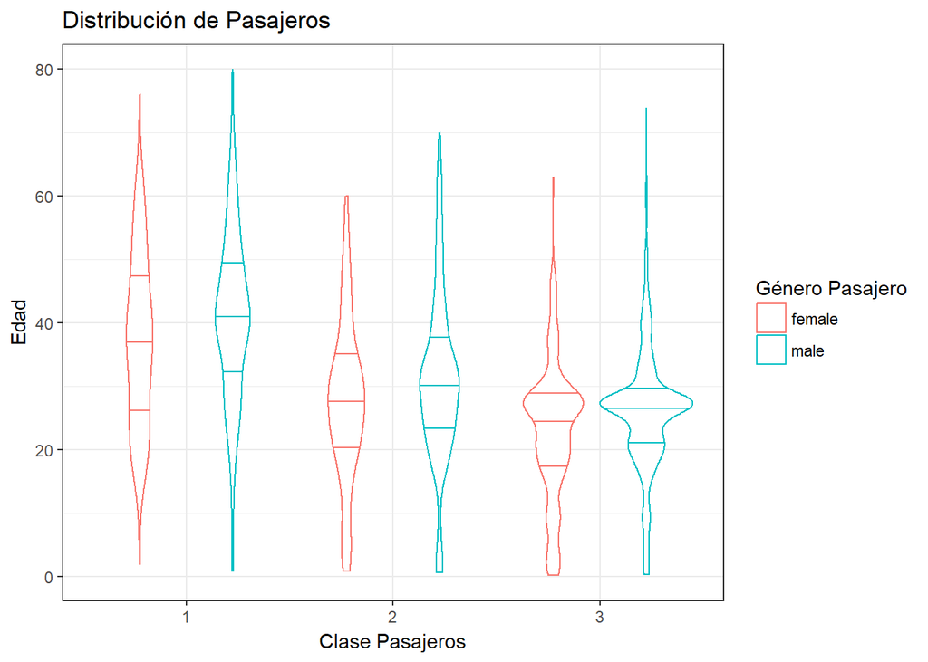

```r
ggplot(data = data) +
  geom_violin (aes(Pclass, Age, colour = factor(Sex)),draw_quantiles = c(0.25, 0.5, 0.75)) +
  labs (title = "Distribución de Pasajeros", x= "Clase Pasajeros",
        y = "Edad" , colour = "Género Pasajero") +
  theme_bw()
```

Representando la edad de los pasajeros obtenemos:

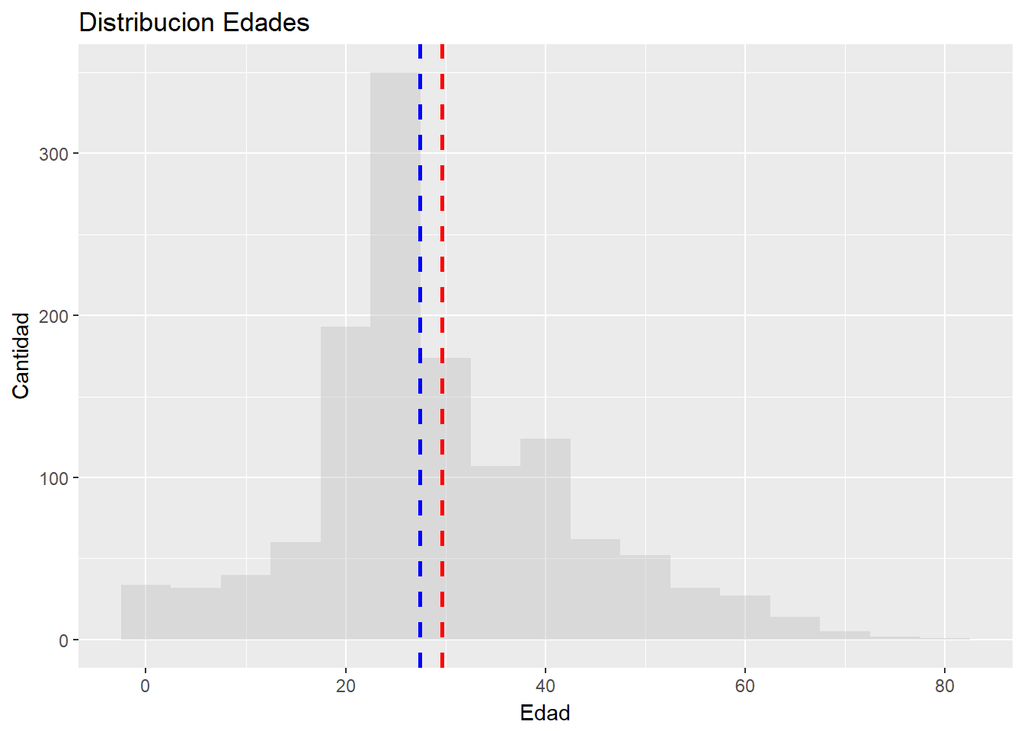

```r
#Test_age <- na.omit(data$Age)
#Test_age <- as.integer(Test_age)
ggplot(data,  aes(x = Age)) +
  geom_histogram(binwidth = 5, fill = 'grey', alpha=0.4) +
  geom_vline(aes(xintercept=median(Age, na.rm=T)),
    colour='blue', linetype='dashed', lwd=1) +
  geom_vline(aes(xintercept=mean(Age, na.rm=T)),
  colour='red', linetype='dashed', lwd=1) +
  labs (title = "Distribucion Edades", x= "Edad", y = "Cantidad" )
```

Finalmente realizando unos gráficos de las variables principales, clase, sexo y puerto de embarque.

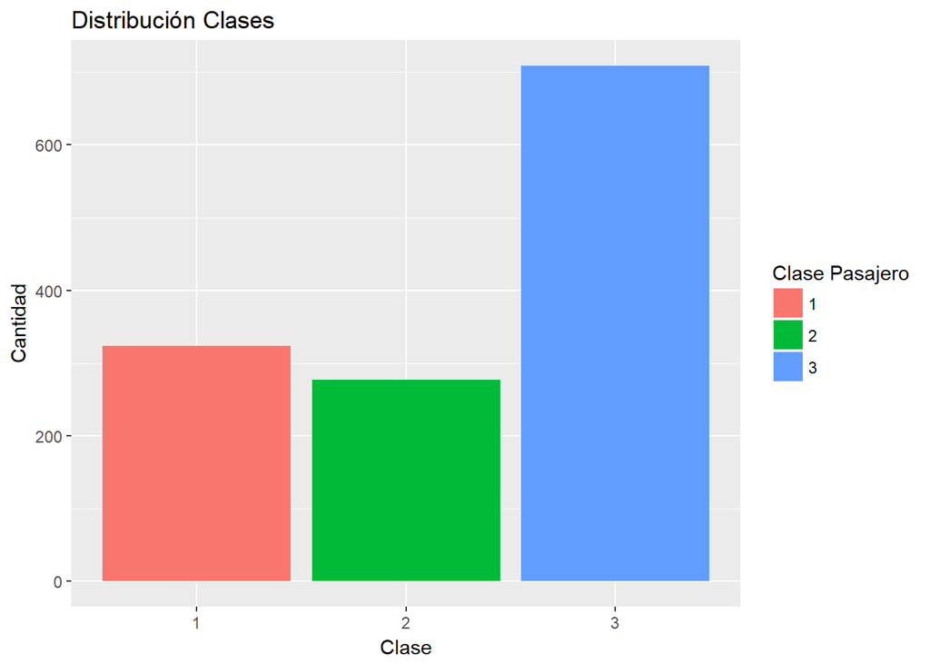

```r
par(mfrow=c(1,2))
ggplot(data,  aes(x = Pclass)) +
  geom_histogram(aes(fill = Pclass) ,stat = "count") +
  labs (title = "Distribución Clases", x= "Clase", y = "Cantidad", fill = "Clase Pasajero")
```

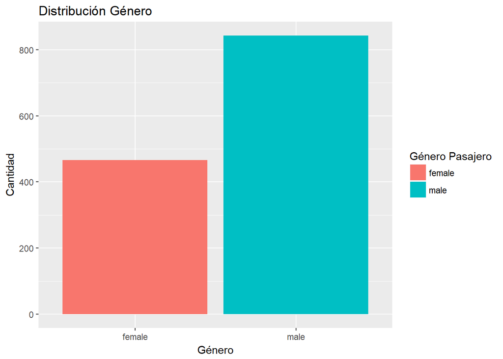

```r
qplot(Sex, data = data,  fill= Sex) +
  labs (title = "Distribución Género", x= "Género", y = "Cantidad", fill = "Género Pasajero")
```

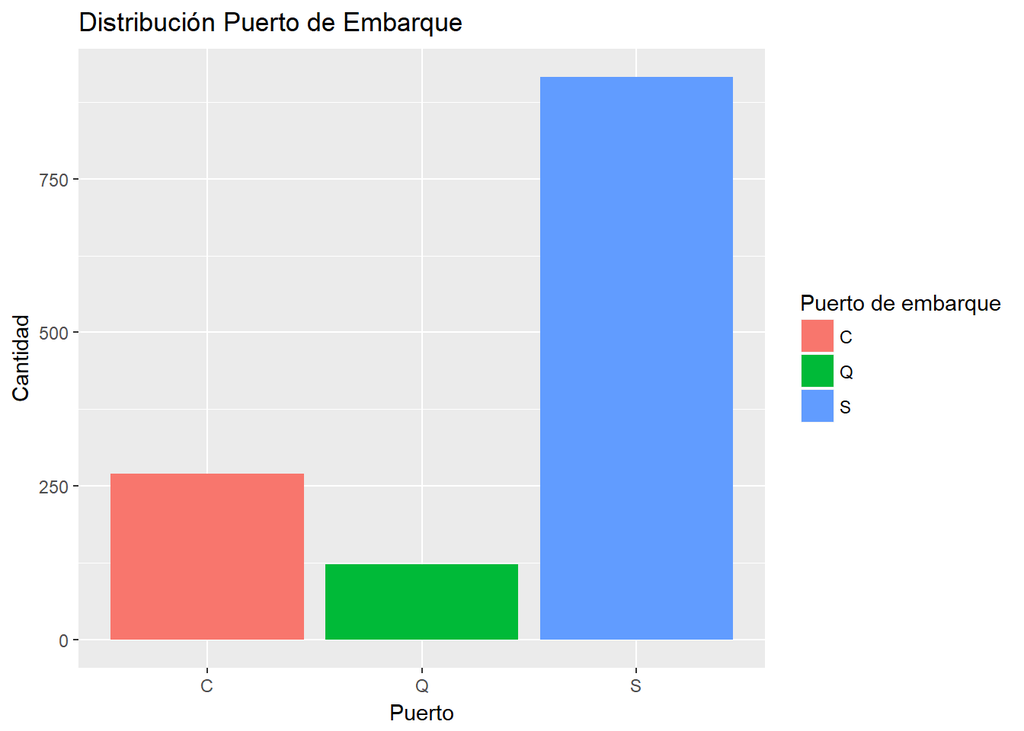

```r
qplot(Embarked, data = data,  fill= Embarked) +
  labs (title = "Distribución Puerto de Embarque", x= "Puerto",
        y = "Cantidad", fill = "Puerto de embarque")
```

Observamos que la clase más numerosa es la 3ra clase, el sexo predominante es el masculino y el puerto dónde hubo mayor embarque es el de Southampton, al ser el puerto de origen del trasatlántico.

También resultará interesante, ver que grupos obtuvieron mayor supervivencia:

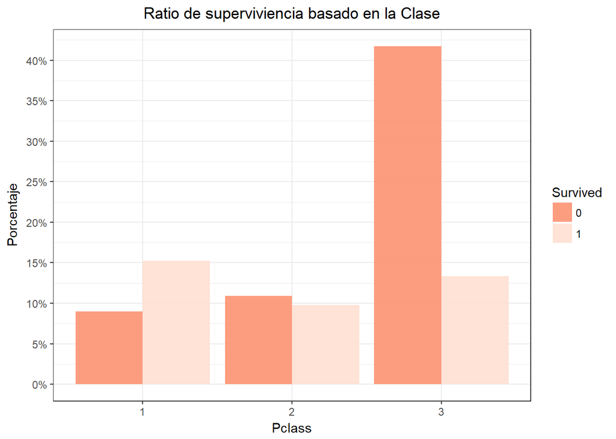

```r
#Respecto a la Clase
ggplot(filter(data, is.na(Survived)==FALSE), aes(Pclass, fill=Survived)) +
  geom_bar(aes(y = (..count..)/sum(..count..)), alpha=0.9, position="dodge") +
  scale_fill_brewer(palette = "Reds", direction = -1) +
  scale_y_continuous(labels=percent, breaks=seq(0,0.6,0.05)) +
  ylab("Porcentaje") +
  ggtitle("Ratio de superviviencia basado en la Clase") +
  theme_bw() +
  theme(plot.title = element_text(hjust = 0.5))
```

Representamos la supervivencia respecto al sexo.

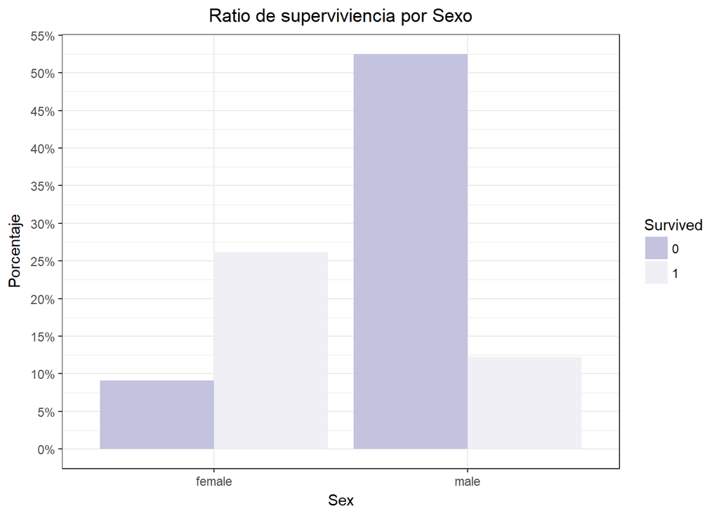

```r
#Respecto al sexo
ggplot(filter(data, is.na(Survived)==FALSE), aes(Sex, fill=Survived)) +
  geom_bar(aes(y = (..count..)/sum(..count..)), alpha=0.9, position="dodge") +
  scale_fill_brewer(palette = "Purples", direction = -1) +
  scale_y_continuous(labels=percent, breaks=seq(0,0.6,0.05)) +
  ylab("Porcentaje") +
  ggtitle("Ratio de superviviencia por Sexo") +
  theme_bw() +
  theme(plot.title = element_text(hjust = 0.5))
```

Representamos la supervivencia respecto al título.

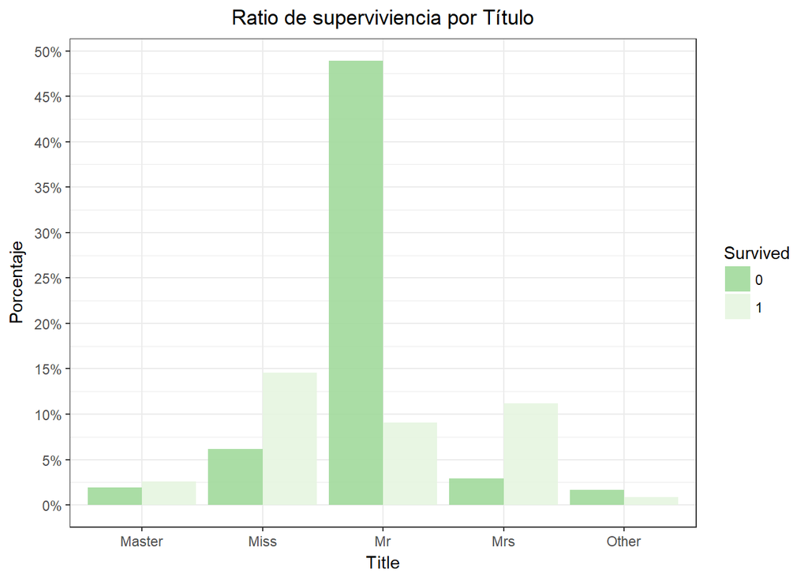

```r
#Respecto al título
ggplot(filter(data, is.na(Survived)==FALSE), aes(Title, fill=Survived)) +
  geom_bar(aes(y = (..count..)/sum(..count..)), alpha=0.9, position="dodge") +
  scale_fill_brewer(palette = "Greens", direction = -1) +
  scale_y_continuous(labels=percent, breaks=seq(0,0.6,0.05)) +
  ylab("Porcentaje") +
  ggtitle("Ratio de superviviencia por Título") +
  theme_bw() +
  theme(plot.title = element_text(hjust = 0.5))
```

**4.2. Comprobación de la normalidad y homogeneidad de la varianza.**

Comprobar la normalidad y homogeneidad de la varianza tiene sentido para la variables numéricas Age y Fare.

Comprobamos la normalidad, gráficamente, para Age:

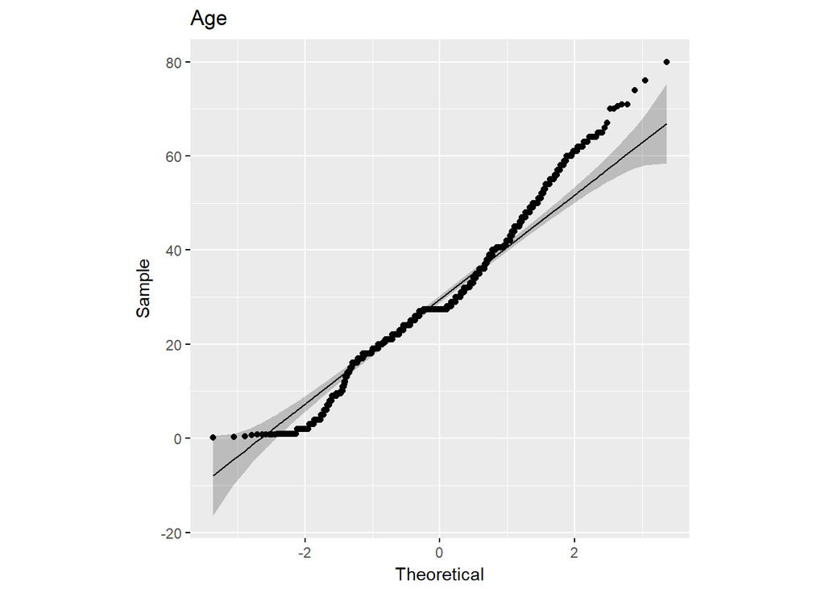

```r
#Hago que los dos ejes tengan el mismo tamaño.
ggqqplot(data$Age, ggtheme = theme(aspect.ratio=1), title = "Age")
```

También se puede aplicar un test Shapiro-Wilk, en el que la hipótesis nula, (H0) es que la muestra proviene de una población normalmente distribuida y la hipótesis alternativa (H1), que la muestra no proviene de una población normalmente distribuida.

```r
# Aplico el test
shapiro.test(data$Age)
```

```
##
##  Shapiro-Wilk normality test
##
## data:  data$Age
## W = 0.97034, p-value = 9.628e-16
```

El valor de W está próximo a 1 y el p-value < 0.05, (el p-value, debería ser p-value>0.05 para seguir una distribución normal) así que se rechaza la hipótesis nula y la muestra no sigue una distribución normal. Como se ve en la gráfica hay menos jóvenes y más con elevada edad que habría en una distribución normal.

A continuación, comprobamos la normalidad de Fare, gráficamente:

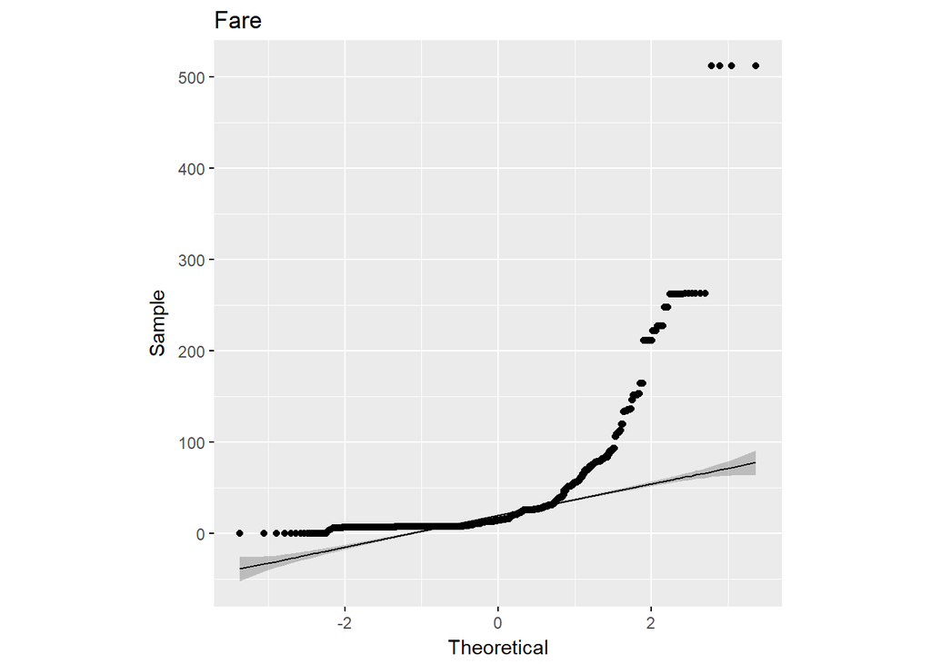

```r
#Hago que los dos ejes tengan el mismo tamaño.
ggqqplot(data$Fare, ggtheme = theme(aspect.ratio=1), title = "Fare")
```

Aplicamos el test de Shapiro-Wilk a la variable Fare

```r
# Aplico el test
shapiro.test(data$Fare)
```

```
##
##  Shapiro-Wilk normality test
##
## data:  data$Fare
## W = 0.52765, p-value < 2.2e-16
```

En este caso ni siquiera W está cercano a 1, así que se rechaza la hipótesis nula y tampoco sigue una distribución normal.

Comprobamos la homogeneidad de la varianza, dado que hemos visto que los datos no siguen una distribución normal, aplicaremos el test de Fligner-Killeen.

```r
# Aplicamos el test de Fligner-Killeen.
fligner.test(Age ~ Fare, data = data)
```

```
##
##  Fligner-Killeen test of homogeneity of variances
##
## data:  Age by Fare
## Fligner-Killeen:med chi-squared = 391.77, df = 280, p-value =
## 1.132e-05
```

Dado que la prueba presenta un p-valor inferior al nivel de significancia (<0.05), se rechaza la hipótesis nula de homocedasticidad y se concluye que la variable Age presenta una varianza estadísticamente diferente para la distribución de Fare.

**4.3. Aplicación de pruebas estadísticas para comparar los grupos de datos.**  
*En función de los datos y el objetivo del estudio, aplicar pruebas de contraste de hipótesis, correlaciones, regresiones, etc.*  
*Aplicar al menos tres métodos de análisis diferentes.*

**1 - Contraste de Hipótesis**  
*Comprobar la hipótesis que la 1ra clase tiene mas posibilidades de Sobrevivir.*

H0 : No hay diferencia significativa de sobrevivir entre la clase alta y la clase baja.  
H1 : La clase alta tiene mas probabilidades de sobrevivir.

```r
Pclass_set <- subset(datostrain, Pclass == 1)
#function for z test
z.test = function(a, b, n){
 sample_mean = mean(a)
 pop_mean = mean(b)
 c = nrow(n)
 var_b = var(b)
 zeta = (sample_mean - pop_mean) / (sqrt(var_b/c))
 return(zeta)
}
#call function
z.test(Pclass_set$Survived, datostrain$Survived, Pclass_set)
```

```
## [1] 7.423828
```

El valor de z de 7.42 afirma la hipótesis alternativa, la clase alta tiene mas probabilidades de sobrevivir.

**2 - Correlación**  
*Comprobación de correlación entre variables*

```r
chisq.test(data$Sex, data$Pclass)
```

```
##
##  Pearson's Chi-squared test
##
## data:  data$Sex and data$Pclass
## X-squared = 20.379, df = 2, p-value = 3.757e-05
```

Dado que el p valor es menor que 0.05, el género y la clase son significantes y deben de tomarse en cuenta para realizar cualquier modelo.

**3 - Regresión**

```r
fit <- glm(Survived ~ Age + Pclass + Sex + SibSp + Parch + Fare + Embarked,
           data = datostrain, family = binomial(link = 'logit'))
summary(fit)
```

```
##
## Call:
## glm(formula = Survived ~ Age + Pclass + Sex + SibSp + Parch +
##     Fare + Embarked, family = binomial(link = "logit"), data = datostrain)
##
## Deviance Residuals:
##     Min       1Q   Median       3Q      Max
## -2.7233  -0.6447  -0.3799   0.6326   2.4457
##
## Coefficients:
##              Estimate Std. Error z value Pr(>|z|)
## (Intercept)  5.637407   0.634550   8.884  < 2e-16 ***
## Age         -0.043350   0.008232  -5.266 1.39e-07 ***
## Pclass      -1.199251   0.164619  -7.285 3.22e-13 ***
## Sexmale     -2.638476   0.222256 -11.871  < 2e-16 ***
## SibSp       -0.363208   0.129017  -2.815  0.00487 **
## Parch       -0.060270   0.123900  -0.486  0.62666
## Fare         0.001432   0.002531   0.566  0.57165
## EmbarkedQ   -0.823545   0.600229  -1.372  0.17005
## EmbarkedS   -0.401213   0.270283  -1.484  0.13770
## ---
## Signif. codes:  0 '***' 0.001 '**' 0.01 '*' 0.05 '.' 0.1 ' ' 1
##
## (Dispersion parameter for binomial family taken to be 1)
##
##     Null deviance: 960.90  on 711  degrees of freedom
## Residual deviance: 632.34  on 703  degrees of freedom
##   (179 observations deleted due to missingness)
## AIC: 650.34
##
## Number of Fisher Scoring iterations: 5
```

Se comprueba que existe una fuerte relación entre la variable dependiente Survived y Edad, Clase y Genero (hombre).

# 5. Representación de los reultados a partir de tablas y gráficas.

Representamos los datos de las variables.

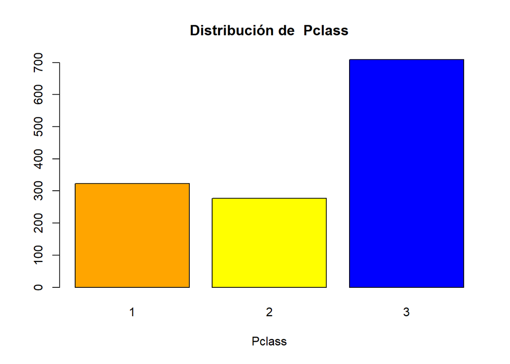

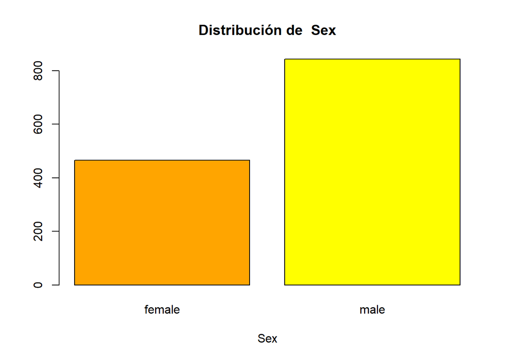

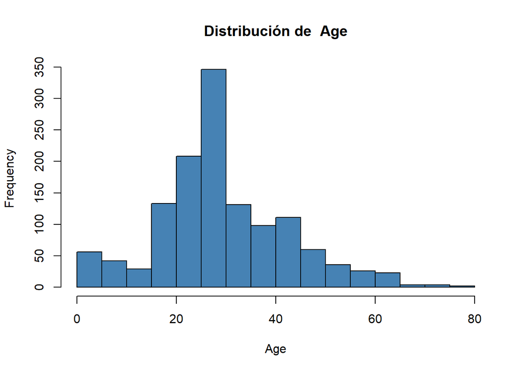

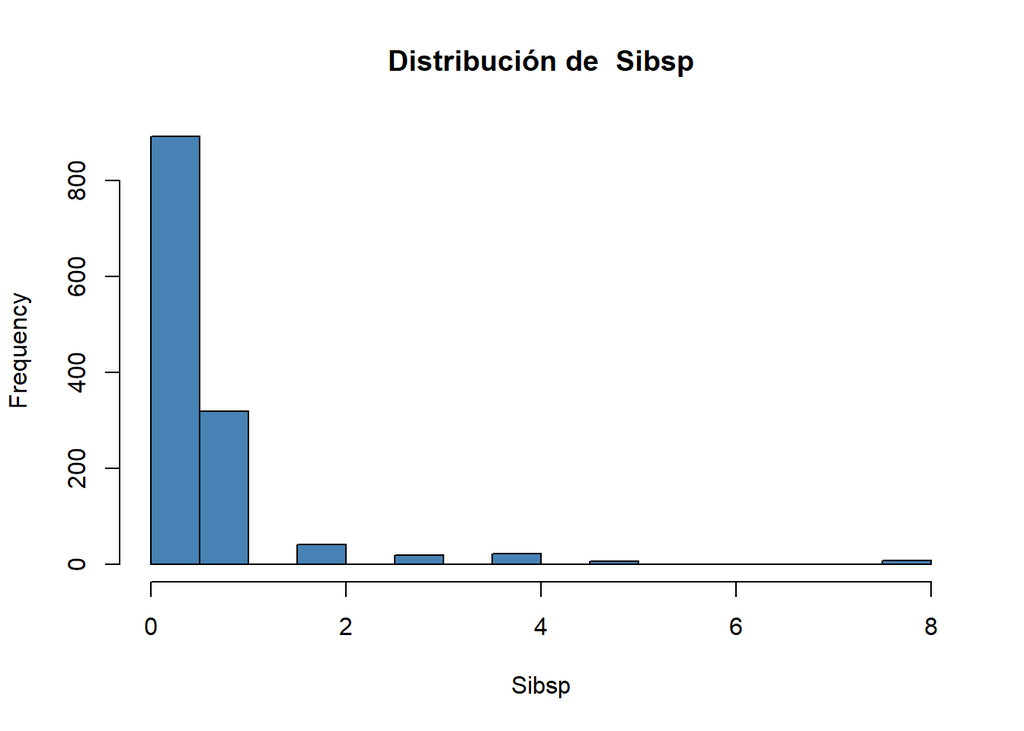

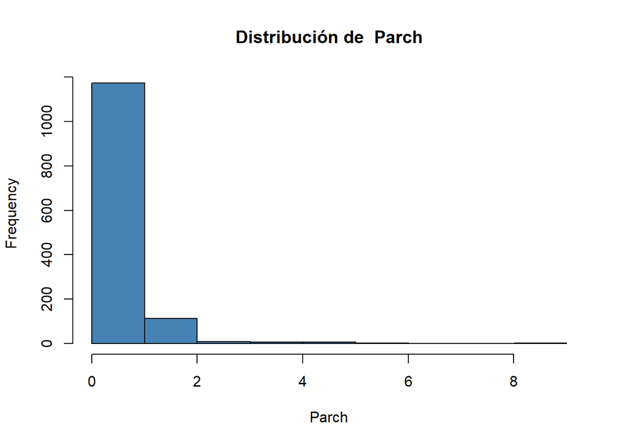

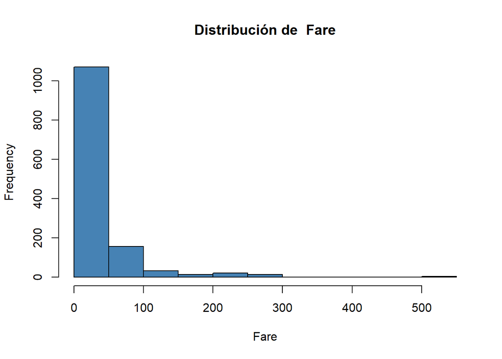

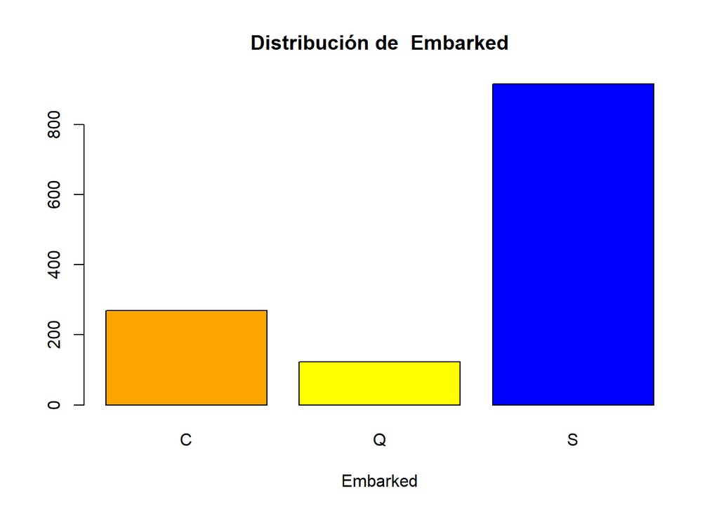

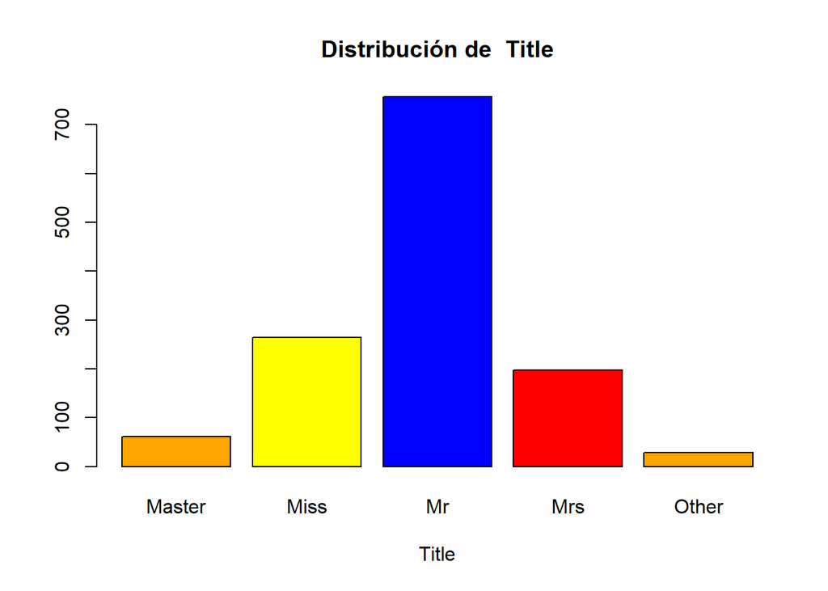

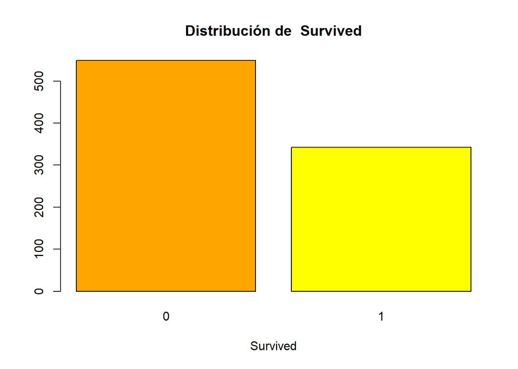

```r
# Mostramos un histograma para cada variable cuantitativa o un gráfico de barras en caso de que
# sea una variable cualitativa.
for (i in 2:ncol(data)) {
  if (class(data[,i]) != "factor" & class(data[,i]) != "character")  {
    hist(data[,i], freq = TRUE, col = c("steelblue"),
         main=paste("Distribución de ",
                    str_to_title(str_replace(colnames(data[i]), "_", " ")), sep = " "),
         xlab= str_to_title(str_replace(colnames(data[i]), "_", " ")))
  }
  else {
    if (class(data[,i]) != "character") {
      barplot(table(data[,i]),
            col = c("orange","yellow","blue","red"),
            main=paste("Distribución de ",
                    str_to_title(str_replace(colnames(data[i]), "_", " ")), sep = " "),
            xlab= str_to_title(str_replace(colnames(data[i]), "_", " ")))
    }
  }
}
```

Creamos un gráfico scatter plot, para ver la correlación de las variables:

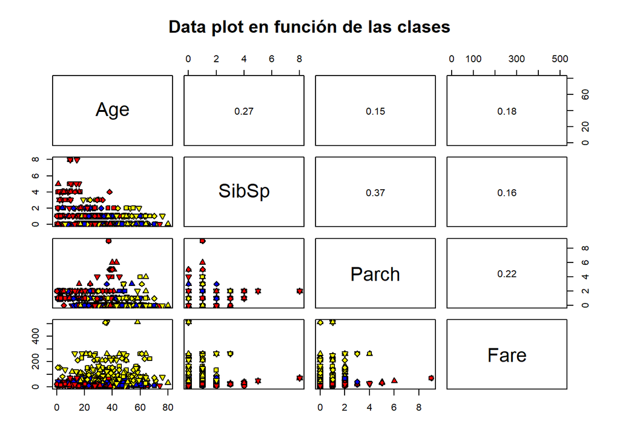

```r
# Referencia:
# https://warwick.ac.uk/fac/sci/moac/people/students/peter_cock/r/iris_plots/
# Función para mostrar la correlación
panel.pearson <- function(x, y, ...) {
horizontal <- (par("usr")[1] + par("usr")[2]) / 2;
vertical <- (par("usr")[3] + par("usr")[4]) / 2;
text(horizontal, vertical, format(abs(cor(x,y)), digits=2))
}
# Gráfico de parejas
pairs(data[c(5,6,7,9)], main = "Data plot en función de las clases", pch = c(22,23,24,25),
      bg = c("yellow","blue","red") [unclass(data[,'Pclass'])],
      upper.panel = panel.pearson)
```

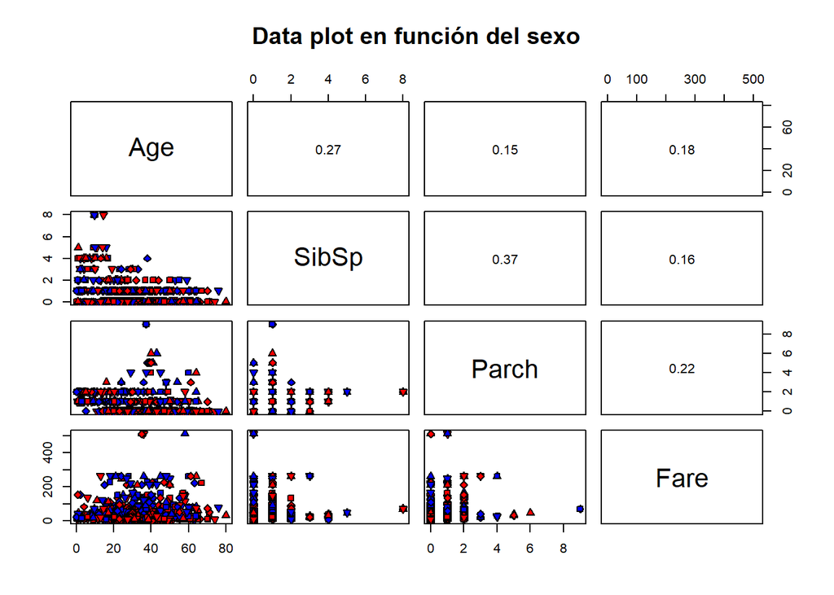

```r
# Referencia:
# https://warwick.ac.uk/fac/sci/moac/people/students/peter_cock/r/iris_plots/
# Función para mostrar la correlación
panel.pearson <- function(x, y, ...) {
horizontal <- (par("usr")[1] + par("usr")[2]) / 2;
vertical <- (par("usr")[3] + par("usr")[4]) / 2;
text(horizontal, vertical, format(abs(cor(x,y)), digits=2))
}
# Gráfico de parejas
pairs(data[c(5,6,7,9)], main = "Data plot en función del sexo", pch = c(22,23,24,25),
      bg = c("blue","red") [unclass(data[,'Sex'])],
      upper.panel = panel.pearson)
```

En los gráficos anteriores no se observa ninguna relación de dependencia a simple vista entre las variables.

Antes de pasar a la resolución del problema en sí, de predecir la variable Survived en el conjunto de test, podemos guardar los resultados de los conjuntos de datos tratados.

Para ello, volvemos a separar los datos, tomando sólo las columnas que utilizaremos para la predicción. No se utilizan los datos de Cabin ni de Ticket. Los datos de Name, se han tratado y sustituido por Title.

```r
# Referencia
# https://www.kaggle.com/thilakshasilva/predicting-titanic-survival-using-five-algorithms#exploratory-data-analysis
# Volvemos a partir el conjunto de datos
titanic_train <- data[1:891, c("Survived","Pclass","Sex","Age","SibSp","Parch","Fare","Embarked","Title")]
titanic_test <- data[892:1309, c("Pclass","Sex","Age","SibSp","Parch","Fare","Embarked","Title")]
```

Y guardamos los archivos:

```r
# Guardamos el archivo
write.csv(titanic_train, file = './output/titanic_train_treated.csv', row.names = FALSE, quote=FALSE)
write.csv(titanic_test, file = './output/titanic_test_treated.csv', row.names = FALSE, quote=FALSE)
```

# 6. Resolución del problema.

**A partir de los resultados obtenidos. ¿cuáles son las conclusiones?. ¿Los resultados permiten responder al problema?**

Como se trata de predecir una variable binaria, podemos crear un modelo de regresión logística que sea función de las otras variables.

```r
# Volvemos a partir el conjunto de datos
set.seed(198)
particion = sample.split(titanic_train$Survived, SplitRatio = 0.8)
train = subset(titanic_train, particion == TRUE)
test = subset(titanic_train, particion == FALSE)
```

```r
# Referencia:
# https://rpubs.com/emilopezcano/logit
# Modelo de regresión logística
titanic.logit <- glm(Survived ~ Pclass + Sex + Age + SibSp + Parch + Fare + Embarked + Title,
                    data = titanic_train, family = "binomial"(link="logit"))
summary(titanic.logit)
```

```
##
## Call:
## glm(formula = Survived ~ Pclass + Sex + Age + SibSp + Parch +
##     Fare + Embarked + Title, family = binomial(link = "logit"),
##     data = titanic_train)
##
## Deviance Residuals:
##     Min       1Q   Median       3Q      Max
## -2.3878  -0.5480  -0.3801   0.5353   2.5499
##
## Coefficients:
##               Estimate Std. Error z value Pr(>|z|)
## (Intercept)  19.665733 504.958265   0.039 0.968934
## Pclass2      -1.130844   0.330031  -3.426 0.000611 ***
## Pclass3      -2.243296   0.331563  -6.766 1.33e-11 ***
## Sexmale     -15.212933 504.957877  -0.030 0.975966
## Age          -0.028446   0.009691  -2.935 0.003331 **
## SibSp        -0.569158   0.126612  -4.495 6.95e-06 ***
## Parch        -0.361322   0.135575  -2.665 0.007697 **
## Fare          0.003362   0.002653   1.267 0.205055
## EmbarkedQ    -0.071733   0.395059  -0.182 0.855916
## EmbarkedS    -0.408573   0.251683  -1.623 0.104512
## TitleMiss   -15.772521 504.958131  -0.031 0.975082
## TitleMr      -3.508822   0.540508  -6.492 8.49e-11 ***
## TitleMrs    -14.972348 504.958197  -0.030 0.976346
## TitleOther   -3.543153   0.781496  -4.534 5.79e-06 ***
## ---
## Signif. codes:  0 '***' 0.001 '**' 0.01 '*' 0.05 '.' 0.1 ' ' 1
##
## (Dispersion parameter for binomial family taken to be 1)
##
##     Null deviance: 1186.66  on 890  degrees of freedom
## Residual deviance:  724.73  on 877  degrees of freedom
## AIC: 752.73
##
## Number of Fisher Scoring iterations: 13
```

```r
# Modelo de regresión logística
titanic.logit <- step(titanic.logit)
```

```
## Start:  AIC=752.73
## Survived ~ Pclass + Sex + Age + SibSp + Parch + Fare + Embarked +
##     Title
##
##            Df Deviance    AIC
## - Embarked  2   727.94 751.94
## - Fare      1   726.55 752.55
## <none>          724.73 752.73
## - Sex       1   730.19 756.19
## - Parch     1   732.36 758.36
## - Age       1   733.75 759.75
## - SibSp     1   750.31 776.31
## - Pclass    2   774.74 798.74
## - Title     4   782.95 802.95
##
## Step:  AIC=751.94
## Survived ~ Pclass + Sex + Age + SibSp + Parch + Fare + Title
##
##          Df Deviance    AIC
## <none>        727.94 751.94
## - Fare    1   730.69 752.69
## - Sex     1   733.31 755.31
## - Parch   1   736.27 758.27
## - Age     1   737.68 759.68
## - SibSp   1   756.65 778.65
## - Pclass  2   780.00 800.00
## - Title   4   786.70 802.70
```

```r
# Modelo de regresión logística
summary(titanic.logit)
```

```
##
## Call:
## glm(formula = Survived ~ Pclass + Sex + Age + SibSp + Parch +
##     Fare + Title, family = binomial(link = "logit"), data = titanic_train)
##
## Deviance Residuals:
##     Min       1Q   Median       3Q      Max
## -2.4621  -0.5405  -0.3886   0.5325   2.6471
##
## Coefficients:
##               Estimate Std. Error z value Pr(>|z|)
## (Intercept)  19.410542 498.876533   0.039 0.968963
## Pclass2      -1.223069   0.324793  -3.766 0.000166 ***
## Pclass3      -2.248701   0.321985  -6.984 2.87e-12 ***
## Sexmale     -15.189027 498.876155  -0.030 0.975711
## Age          -0.029122   0.009569  -3.043 0.002340 **
## SibSp        -0.593281   0.125619  -4.723 2.33e-06 ***
## Parch        -0.373677   0.134520  -2.778 0.005472 **
## Fare          0.004043   0.002633   1.535 0.124694
## TitleMiss   -15.741626 498.876416  -0.032 0.974828
## TitleMr      -3.554349   0.537396  -6.614 3.74e-11 ***
## TitleMrs    -14.973049 498.876481  -0.030 0.976056
## TitleOther   -3.514816   0.775871  -4.530 5.89e-06 ***
## ---
## Signif. codes:  0 '***' 0.001 '**' 0.01 '*' 0.05 '.' 0.1 ' ' 1
##
## (Dispersion parameter for binomial family taken to be 1)
##
##     Null deviance: 1186.66  on 890  degrees of freedom
## Residual deviance:  727.94  on 879  degrees of freedom
## AIC: 751.94
##
## Number of Fisher Scoring iterations: 13
```

```r
# Modelo de regresión logística
titanic.logit <- step(titanic.logit)
```

```
## Start:  AIC=751.94
## Survived ~ Pclass + Sex + Age + SibSp + Parch + Fare + Title
##
##          Df Deviance    AIC
## <none>        727.94 751.94
## - Fare    1   730.69 752.69
## - Sex     1   733.31 755.31
## - Parch   1   736.27 758.27
## - Age     1   737.68 759.68
## - SibSp   1   756.65 778.65
## - Pclass  2   780.00 800.00
## - Title   4   786.70 802.70
```

Aplicando la función VIF, para hallar el factor de inflación variable generalizado (GVIF).

```r
# Modelo de regresión logística
vif(titanic.logit)
```

```
##                GVIF Df GVIF^(1/(2*Df))
## Pclass 2.169085e+00  2        1.213582
## Sex    6.818832e+06  1     2611.289253
## Age    1.991458e+00  1        1.411190
## SibSp  1.614081e+00  1        1.270465
## Parch  1.458854e+00  1        1.207830
## Fare   1.586248e+00  1        1.259464
## Title  1.492792e+07  4        7.884060
```

Podemos observar la multicolinealidad entre las variables Sex y Title, de todas formas, dejamos la variable Sex, porque al suprimirla el valor de AIC se incrementa.

```r
# Modelo de regresión logística
durbinWatsonTest(titanic.logit)
```

```
##  lag Autocorrelation D-W Statistic p-value
##    1       0.0204161      1.958783   0.568
##  Alternative hypothesis: rho != 0
```

El modelo parece bastante bueno teniendo un p-valor >0.05.

```r
# Comprobamos los resultados en el conjunto de test de validación
prob_pred = predict(titanic.logit, type = 'response', newdata = test)
y_pred = ifelse(prob_pred > 0.5, 1, 0)
head(y_pred)
```

```
##  1  2 12 13 16 22
##  0  1  1  0  1  0
```

Comprobamos la matriz de confusion

```r
# Comprobamos la matriz de confusión
table(test$Survived, y_pred> 0.5 )
```

```
##
##     FALSE TRUE
##   0    97   13
##   1    17   51
```

```r
#kable(table) %>%
#  kable_styling(bootstrap_options = "striped", full_width = F, position = "left")
```

Calculamos la precisión del modelo.

```r
error <- mean(test$Survived != y_pred) # Misclassification error
paste('Accuracy',round(1-error,4))
```

```
## [1] "Accuracy 0.8315"
```

Finalmente, calculamos los valores finales

```r
# Calculamos las predicciones
titanic_prob = predict(titanic.logit, newdata = titanic_test)
titanic_pred = ifelse(titanic_prob > 0.5, 1, 0)
```

```r
# Guardamos los resultados
results <- data.frame(PassengerID = data[892:1309,"PassengerId"], Survived = titanic_pred)
```

```r
# Guardamos el archivo
write.csv(results, file = './output/PrediccionSupervivenciaTitanic.csv', row.names = FALSE, quote=FALSE)
```

Los resultados han permitido responder al problema, dando una puntuación de 0.80382, cuando los datos fueron subidos a kaggle, que es bastante mejor que lo que sería un predictor aleatorio. A partir de aquí se podría mejorar el modelo de predicción considerando otros métodos y creando por ejemplo un “stacking”" de ellos.

# 7. Código. Hay que adjuntar el código, preferiblemente en R, con el que se ha realizado la limpieza, análisis y represntación de los datos.

El código está integrado en el documento .Rmd y sale convenientemente formateado cuando se exporta por Knit en .html o .pdf.

Participación de los integrantes del equipo:

```r
# Creamos una tabla en formato kagle para mostrar la participación:
participantes <-  c("Investigación previa", "L.G, J.L.M.",
                    "Redacción de las respuestas", "L.G, J.L.M.",
                    "Desarrollo código", "L.G, J.L.M.")
df <- matrix(participantes, ncol = 2, byrow = TRUE)
colnames(df) <- c("Contribuciones", "Firmas")
kable(df) %>%
  kable_styling(bootstrap_options = "striped", full_width = F, position = "left")
```

| Contribuciones | Firmas |
| --- | --- |
| Investigación previa | L.G, J.L.M. |
| Redacción de las respuestas | L.G, J.L.M. |
| Desarrollo código | L.G, J.L.M. |

# 8. Bibliografía.

Baayen, R Harald. 2008. *Analyzing Linguistic Data: A Practical Introduction to Statistics Using R*. Cambridge University Press.

Calvo, Laia; Pérez, Mireia; Subirats. 2019. *Introducción a La Limpieza Y Análisis de Los Datos*. Universitat Oberta de Catalunya, UOC.

Gibergans Bàquena, J. 2009. *Regresión Lineal Simple*. Universitat Oberta de Catalunya, UOC.

Gibergans Bàquena, Josep. 2009. *Regresión Lineal Múltiple*. Universitat Oberta de Catalunya, UOC.

Gillén Estany, Montserrat. 2017. *Modelización Predictiva: Introducción a Los Modelos Lineales Generalizados*. Universitat Oberta de Catalunya, UOC.

Hothorn, Torsten, and Brian S Everitt. 2014. *A Handbook of Statistical Analyses Using R*. CRC press.

*Https://Rpubs.com/Emilopezcano/Logit*. Accedido 02/06/2019.

*Https://Www.kaggle.com/c/Titanic*. Accedido 01/06/2019.

*Https://Www.kaggle.com/Thilakshasilva/Predicting-Titanic-Survival-Using-Five-Algorithms#exploratory-Data-Analysis*. Accedido 01/06/2019.

Teetor, Paul. 2011. *R Cookbook: Proven Recipes for Data Analysis, Statistics, and Graphics*. “ O’Reilly Media, Inc.”

Vegas Lozano, Esteban. *Preprocesamiento de Los Datos*. Universitat Oberta de Catalunya, UOC.